# AE 20: Intro to Linear Models

2021-11-02

```r
library(tidyverse)
library(tidymodels)
library(scatterplot3d)
```

# Bulletin

# Learning goals

- Understand the language and notation of linear modeling.
- Use `tidymodels` to make inference under a linear regression model

To begin, let’s load the data. Again, we’ll work with the pokemon data from last week.

```r
pokemon <- read_csv("data/pokemon.csv")
```

# The language of linear modeling

What is a linear model?

A linear model is a simple way to mathematically model the relationship between two or more observed phenomena.

## Exercise 1)

Is there a relationship between a pokemon’s size and their hit points (hp)? Specifically, does a pokemon’s height/weight tell us something about how many hit points they have?

Create two scatterplots, one for hp vs height and another illustrating hp vs weight.

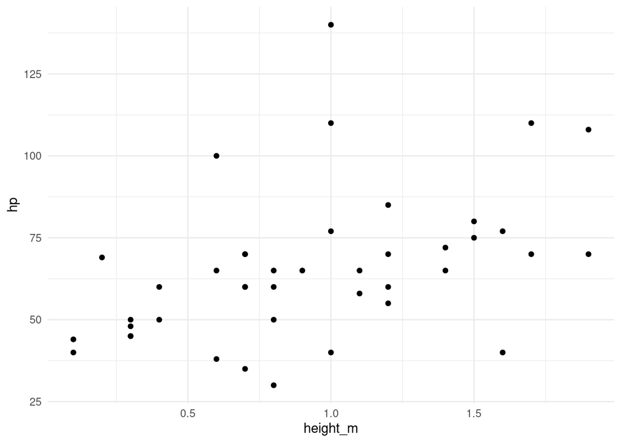

```r
# code here
pokemon %>%
  ggplot(aes(x = height_m, y = hp)) +
  geom_point() +
  theme_minimal()
```

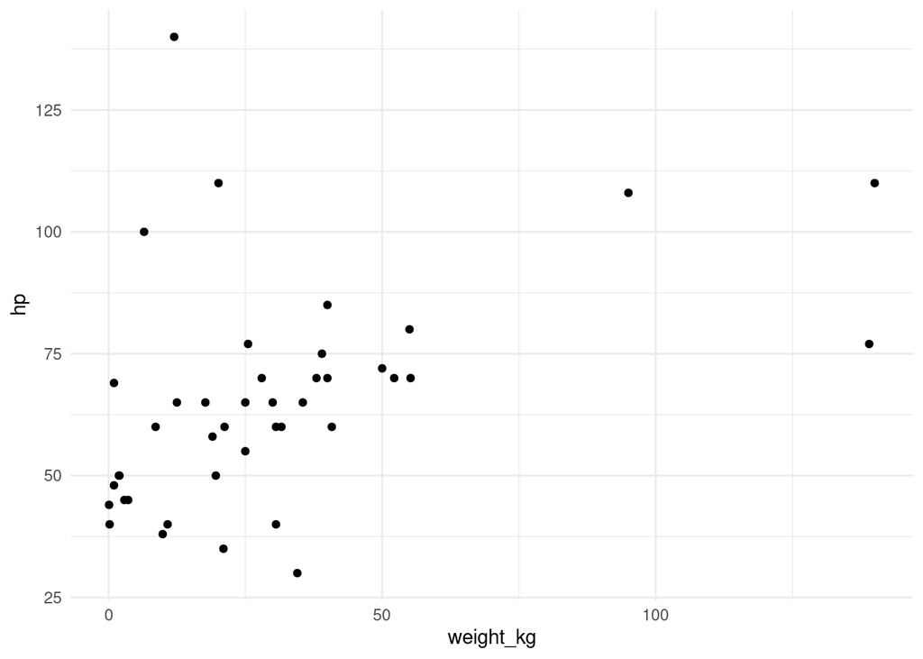

```r
pokemon %>%
  ggplot(aes(x = weight_kg, y = hp)) +
  geom_point() +
  theme_minimal()
```

Describe the relationship you see here.

Label the following:

Response variable:

Explanatory variable(s):

## Exercise 2)

For now, let’s focus on just two of these variables, namely hp and height.

Write down a model (using $x$, $y$, $\beta$ notation) that describes a linear relationship between hp and height. Define each variable.

$y = \beta_0 + \beta_1 x$

where

y: hp

x: height

$\beta_0, \beta_1$: **parameters** of the model that we want to learn.

If we measured all pokemon, there is a true $\beta_0$ and $\beta_1$ that describe this relationship for the population.

Since all we observe is a sample of $42$ pokemon, we will come up with estimates $\hat{\beta_0}$ and $\hat{\beta_1}$ that best “fit” the data.

$\hat{y} = \hat{\beta_0} + \hat{\beta_1} x$

How might we do this?

Talk through minimizing sum of residuals, sum of abs value residuals, sum of residuals squared.

## Exercise 3)

[Click here](https://seeing-theory.brown.edu/regression-analysis/index.html#section1) to interact with an ordinary least squares (OLS) linear regression model.

Select I and move the data points around.

Describe what you see.

## Exercise 4)

Now let’s fit a ordinary least squares `lm`.

Use functions from the preparation video/slides to fit a linear model to `hp` and `height` as described in exercise 2. Save the model in a variable entitled `hp_height_fit`.

```r
# code here
hp_height_fit = linear_reg() %>%
  set_engine("lm") %>%
  fit(hp ~ height_m, data = pokemon)
# notice no tidy() for plotting purposes later
```

Write out the equation of the fitted model.

$y = 46.5 + 20.3 x$

Uncomment and fill in blanks below to visualize the linear model on top of the scatterplot from Exercise 1.

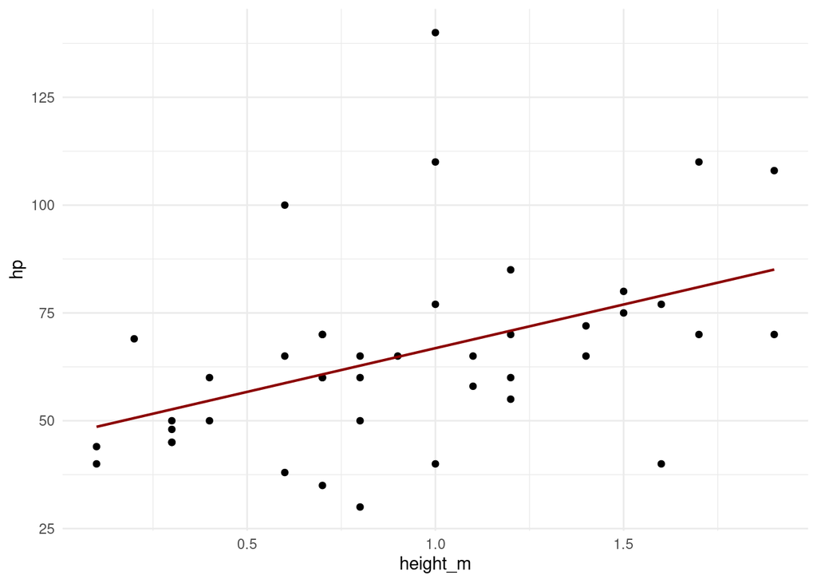

```r
hp_height_fit_aug <- augment(hp_height_fit$fit) # need $fit for plotting

# hp_height_fit_aug %>%
#   ggplot() +
#   geom_point(aes(___, ___)) +
#   geom_line(aes(x = ___, y = .fitted), size = 0.75, color = "darkred") +
#   theme_minimal()

hp_height_fit_aug %>%
  ggplot() +
  geom_point(aes(x = height_m, y = hp)) +
  geom_line(aes(x = height_m, y = .fitted), size = 0.75, color = "darkred") +
  theme_minimal()
```

## Exercise 5)

Use the equation of the fitted model to predict the hp of an unknown pokemon with a height of 1.1 meters.

```r
46.5 + (20.3*1.1)
```

```
## [1] 68.83
```

```r
# alternatively, with the model we can check:
unknown_pokemon = data.frame(height_m = 1.1)
predict(hp_height_fit, unknown_pokemon)
```

| .pred |
| --- |
| 68.85394 |

If you were asked to predict the hp of a pokemon that is 2.5 meters tall, is this model appropriate? Why or why not?

Possibly not – we would be extrapolating beyond the range of observed values. Maybe pokemon above 2m tall have a different height, hp relationship.

## Exercise 6)

What about a linear model with multiple explanatory variables?

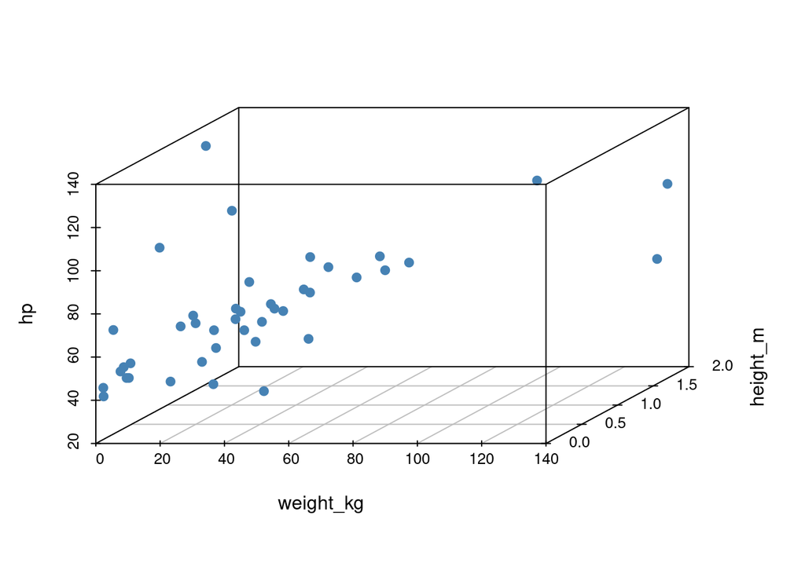

```r
scatterplot3d(pokemon[,c("weight_kg", "height_m", "hp")], pch = 19, color="steelblue")
```

Describe what you see.

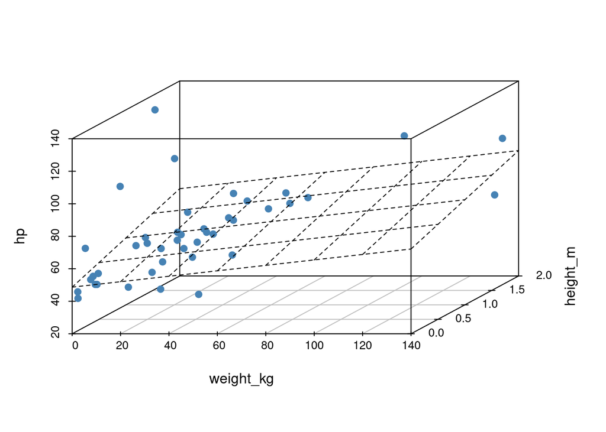

Discuss dimensionality. Outline of talking points:

In 1-D, a linear equation is a point.

In 2-D, a linear equation is a line.

In 3-D, a linear equation is a plane.

In N-D a linear equation is a N-1 dimensional “hyperplane”.

In all cases, the $\beta$ fully specify our linear equation. Thus fitting a linear model means finding $\beta$ which in turn means finding the hyperplane that “best fits” (according to least squares or possibly some other criterion) the data.